# Data Visualization and Reproducible Research

> Greg Dills.

Learn more about me in my [GitHub profile page](https://github.com/gdills)

The following is a sample of products created during the *“Data Visualization and Reproducible Research”* course in Fall 2020.

## Project 01

In the `project_01/` folder you can find an analysis of Netflix Shows and their corresponding user ratings. I created various plots to illustrate the distribution of user ratings and movie ratings.

**Sample data visualization:**

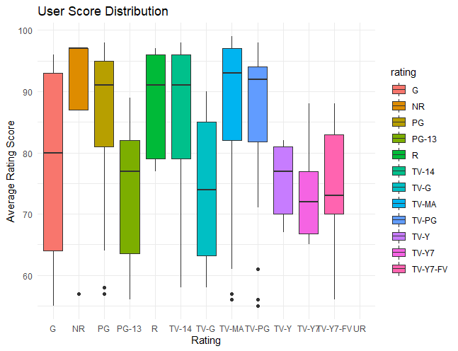

## Project 02

In this project, I explored Florida Lake Shape files and how the size of lakes may correlate to Florida County populations. Find the code and report in the `project_02/` folder.

**Sample data visualization:**

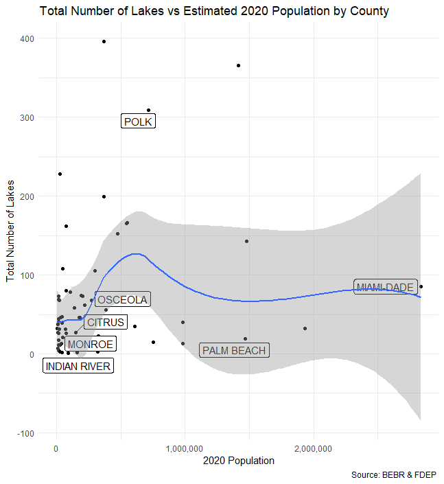

## Project 03

In this project, I explored comments from a rate my professor data set. Very interesting to perform text analysis on user comments. I ended up creating a bing sentiment analysis which compares individual professors at an institution.

**Sample data visualization:**

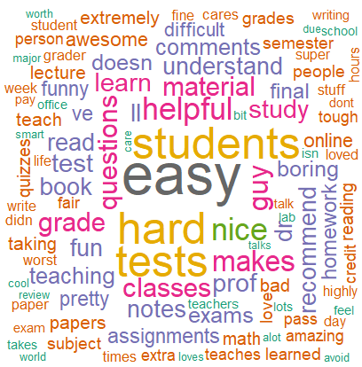

### Moving Forward

This course did an exceptional job teaching me the fundamentals of both `R` and proper visualization/reproducilbe research techniques. I believe the biggest takeaways are:

- **Github:** Prior to this course I did not know much about Github and I am much more confident to utilize git.
- **Markdown:** I can’t get enough of markdown and enjoy using it (almost) daily.
- **Psychology behind Visuals:** There is more to producing a plot than `ggplot %>% geom_bar...` This course helped me to understand the science behind producing great visuals.